# Assignment 2: Gene Expression Analysis and Preliminary ORA

Koji Wong

03/11/2025

# 1 Introduction

In our last assignment, we performed data preprocessing, filtering, and normalization on a GEO dataset. Particularly, this GEO dataset was titled “Elevated GRHL2 imparts plasticity in estrogen receptor positive breast cancer cells [RNA-seq]” with the GEO accession GSE272061. This dataset is associated with the 2024 paper by Zheng et al. titled “Elevated GRHL2 Imparts Plasticity in ER-Positive Breast Cancer Cells” which can be obtained [here](https://www.mdpi.com/2072-6694/16/16/2906). This dataset consists of 3 conditions: GFPnegative, GFPpositive, and negative control which was sampled from 5 different patients.

At the start, we found that 57500 genes were in the dataset originally. To create a higher quality dataset, we filtered out genes with low counts to obtain a total of 21975 genes. Next, we mapped the genes to HUGO gene symbols. Some of these genes mapped to empty strings or na, so these were filtered out as well giving us a total of 18863 genes. The count data was then normalized using edgeR which gives us our normalized_matrix that we utilize for analysis in assignment 2.

This normalized matrix can be obtained [here](https://github.com/bcb420-2025/Koji_Wong/raw/refs/heads/main/A2_KojiWong/normalized_matrix.rds) and is downloaded as part of this gene enrichment analysis. Along with that is the DGEList object which can be obtained [here](https://github.com/bcb420-2025/Koji_Wong/raw/refs/heads/main/A2_KojiWong/post_norm_dge.rds) which is also used.

# 2 Differential Gene Expression Analysis

## 2.1 Getting our normalized count data

We first obtain our normalized count data from Assignment 1 by downloading the .rds file associated with it.

```r
# Getting the normalized RNASeq counts from Assignment 1
destfile = "normalized_matrix.rds"
if (!file.exists(destfile)) {
  download.file(
    url = "https://github.com/bcb420-2025/Koji_Wong/raw/refs/heads/main/A2_KojiWong/normalized_matrix.rds",
    destfile = destfile
  )
}
# Load in the normalized count matrix from our rds object file
normalized_matrix <- readRDS(destfile)
head(normalized_matrix)
```

|  | hgnc_symbol | p8-GFPnegative | p8-GFPpositive | p8-negcontrol | p9-GFPnegative | p9-GFPpositive | p9-negcontrol | p10-GFP | p10-GFPpositive | p10-negcontrol | p11-GFP | p11-GFPpositive | p11-negcontrol | p12-GFP | p12-GFPpositive | p12-negcontrol |
| --- | --- | --- | --- | --- | --- | --- | --- | --- | --- | --- | --- | --- | --- | --- | --- | --- |
| A1BG | A1BG | -1.5625170 | -0.7009547 | -1.2798322 | -0.5437205 | -0.5939528 | -0.7234773 | -1.8731068 | -1.5306548 | -1.3354924 | -1.5253851 | -1.82937424 | -1.294467 | -0.7581711 | -1.3590118 | -0.9857297 |
| A1BG-AS1 | A1BG-AS1 | 2.4537148 | 1.7776748 | 1.9679435 | 2.2628191 | 2.1056035 | 2.4618003 | 1.1616979 | 1.2190798 | 1.1266243 | 1.8616288 | 1.56226628 | 1.091480 | 1.1238932 | 1.2459756 | 1.0356131 |
| A2M | A2M | -2.0439972 | -3.3453808 | -2.7309173 | -2.6697976 | -2.7401164 | -3.3453808 | -3.3453808 | -3.3453808 | -2.3387810 | -2.7545055 | -2.26404815 | -2.420752 | -1.0537291 | -3.3453808 | -2.4763050 |
| A2M-AS1 | A2M-AS1 | -0.6739994 | -0.8423217 | -0.5712002 | -1.5845341 | -0.8366179 | -1.3951992 | -1.0255245 | -1.0151997 | -1.3354924 | -1.0093025 | -1.49579133 | -1.146012 | -1.2278291 | -1.1579736 | -0.8740090 |
| A2ML1 | A2ML1 | -1.7832636 | -1.3752492 | -1.7020075 | -0.4251511 | -0.1219395 | -1.9025492 | -0.4951692 | -0.1662887 | -0.8751652 | 0.1301199 | 0.07036591 | -1.646945 | -0.8983946 | -0.5536147 | -1.2390426 |
| A4GALT | A4GALT | 4.6454873 | 5.0864450 | 4.0851495 | 4.4254234 | 5.3619993 | 3.9890890 | 4.0105739 | 4.3266555 | 3.3750224 | 3.4794836 | 3.81177111 | 3.314955 | 3.5221663 | 4.2063678 | 3.5616891 |

## 2.2 Creating a Design Matrix

We create a design matrix as it defines how the samples are structured across conditions, like GFPnegative, GFPpositive, and negative control as well as factors like which patient it is. It tells the statistical model what comparisons to make and which variables to control for.

```r
# Column names of your normalized matrix, except the first column (hgnc_symbol)
sample_names <- colnames(normalized_matrix)[-1]

# Extract conditions and patients
conditions <- rep(c("GFPnegative", "GFPpositive", "negcontrol"), times = 5)
patients <- rep(c("p8", "p9", "p10", "p11", "p12"), each = 3)

# Create a design data frame
design <- data.frame(sample = sample_names, patient = patients, condition = conditions)

# Remove the gene symbols column and keep expression values
expression_data <- as.matrix(normalized_matrix[, -1])
rownames(expression_data) <- normalized_matrix$hgnc_symbol  # Assign gene names as row names

# Create the design matrix including both patient and condition
model_matrix <- model.matrix(~ patient + condition, data = design)

# Check the design matrix
print(head(model_matrix))
```

```
##   (Intercept) patientp11 patientp12 patientp8 patientp9 conditionGFPpositive
## 1           1          0          0         1         0                    0
## 2           1          0          0         1         0                    1
## 3           1          0          0         1         0                    0
## 4           1          0          0         0         1                    0
## 5           1          0          0         0         1                    1
## 6           1          0          0         0         1                    0
##   conditionnegcontrol
## 1                   0
## 2                   0
## 3                   1
## 4                   0
## 5                   0
## 6                   1
```

## 2.3 Fitting models using edgeR

In the previous assignment, I also created a DGEList object off the normalized count data. This step is to bring it back in. this DGEList object stores expression data along with sample groupings and normalization factors.

```r
dge_file = "post_norm_dge.rds"
if (!file.exists(dge_file)) {
  download.file(
    url = "https://github.com/bcb420-2025/Koji_Wong/raw/refs/heads/main/A2_KojiWong/post_norm_dge.rds",
    destfile = dge_file
  )
}
dge <- readRDS(dge_file)
```

## 2.4 Estimate dispersion

The next step is to estimate dispersion. This step is necessary to account for any biological variability between replicates. Dispersion tell us the variability of what is expected versus what is due to random sampling.

```r
d <- edgeR::estimateDisp(dge, model_matrix)
```

## 2.5 Fitting

Next we fit a generalized linear model (GLM) to model the relationship between gene expression and experimental factors such as condition and patient. In this case, we do a QLFTest to compare conditions of GFPpositive versus GFPnegative.

```r
# Fitting the data
fit <- edgeR::glmQLFit(d, model_matrix)

# Calculate differential expression using the Quasi likelihood model
qlf.GFPnegative_vs_GFPpositive <- edgeR::glmQLFTest(fit, coef="conditionGFPpositive")

# Extract DEGs
qlf_output_hits <- edgeR::topTags(qlf.GFPnegative_vs_GFPpositive,
                                  sort.by = "PValue",
                                  n = nrow(normalized_matrix))
```

Now we can see the number of significant differentially expressed genes and the significant genes that pass correction.

```r
sprintf("Number of significant differentially expressed genes with P < 0.05 (edgeR): %d", length(which(qlf_output_hits$table$PValue < 0.05)))
```

```
## [1] "Number of significant differentially expressed genes with P < 0.05 (edgeR): 1683"
```

```r
sprintf("Number of significant genes that pass correction using FDR (edgeR): %d", length(which(qlf_output_hits$table$FDR < 0.05)))
```

```
## [1] "Number of significant genes that pass correction using FDR (edgeR): 167"
```

> 1. Calculate p-values for each of the genes in your expression set. How many genes were significantly differentially expressed? What thresholds did you use and why?

As we can see we found that 1683 genes were significantly differentially expressed. I chose to use 0.05 threshold for p-value as it will indicate that the chance of this gene being differentially expressed is unlikely due to chance.

> 2. Multiple hypothesis testing - correct your p-values using a multiple hypothesis correction method. Which method did you use? And Why? How many genes passed correction?

Out of the DEGs, 167 passed correction. We chose to use the False Discovery Rate (FDR) as we wanted to remove as many false positives as possible while retaining significant genes.

### 2.5.1 Plotting

> 3. Show the amount of differentially expressed genes using an MA Plot or a Volcano plot. Highlight genes of interest.

We plot a volcano plot to visualize the fold change versus p value. Highlighted in red are genes that are significantly differentially expressed. Genes on the left of the split on 0 are downregulated genes while genes on the right are upregulated.

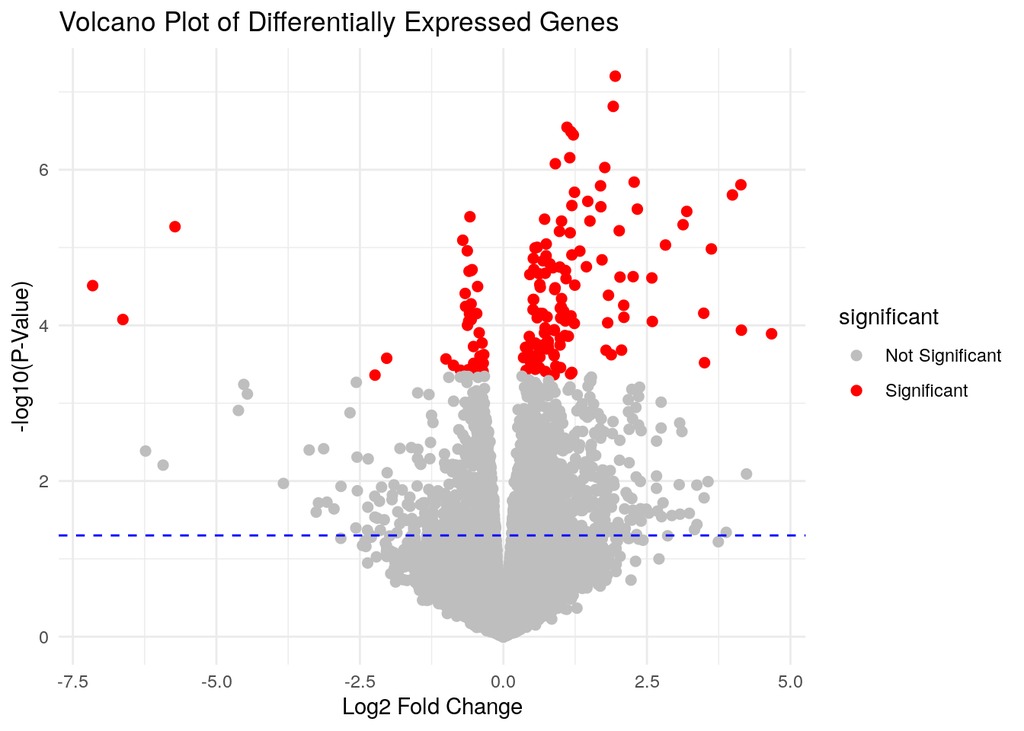

Figure 1. This graph shows all the differentially expressed genes on a volcano plot of log p-value versus log fold change. Genes that are significant (have higher confidence) differentially expressed are highlighted in red. Significant genes with a logFC > 0 on the right of the plot are upregulated and logFC < 0 on the left of the plot are downregulated.

```r
# Extract the results table from topTags output
de_results <- as.data.frame(qlf_output_hits$table)

# Add a column to indicate significance based on adjusted p-value threshold (e.g., < 0.05)
de_results$significant <- ifelse(de_results$FDR < 0.05, "Significant", "Not Significant")

# Create volcano plot
ggplot2::ggplot(de_results, aes(x = logFC, y = -log10(PValue))) +
  geom_point(aes(color = significant), size = 2) +
  scale_color_manual(values = c("Significant" = "red", "Not Significant" = "gray")) +
  theme_minimal() +
  labs(title = "Volcano Plot of Differentially Expressed Genes",
       x = "Log2 Fold Change",
       y = "-log10(P-Value)") +
  theme(legend.position = "right") +
  geom_hline(yintercept = -log10(0.05), linetype = "dashed", color = "blue")
```

### 2.5.2 Heatmap

> 4. Visualize your top hits using a heatmap. Do you conditions cluster together? Explain why or why not.

To visualize our top hits, we took the top 200 hits sorted by p value and mapped these back with the condition data.

```r
# heatmap plot of top 200 DEGs
top_hits <- qlf_output_hits$table[1:200,]

# drop gene symbols
normalized_matrix <- normalized_matrix[,-1]
# Get the normalized expression values for these top hits
top_hits_expression <- normalized_matrix[rownames(top_hits), ]


# Create a sample annotation data frame
# Extract condition from sample names
conditions <- gsub(".*-(.*)", "\\1", colnames(top_hits_expression))

# Group "GFP" and "GFPnegative" together
conditions[conditions == "GFP"] <- "GFPnegative"
# Extract patient information from sample names
patients <- gsub("(p[0-9]+)-.*", "\\1", colnames(top_hits_expression))

# Check the extracted patient information
print(patients)
```

```
##  [1] "p8"  "p8"  "p8"  "p9"  "p9"  "p9"  "p10" "p10" "p10" "p11" "p11" "p11"
## [13] "p12" "p12" "p12"
```

```r
# Create the sample annotation data frame similar to design data frame
sample_annotation <- data.frame(
  Condition = conditions,  # Condition column (GFPnegative, GFPpositive, negcontrol)
  Patient = patients       # Patient column (p8, p9, p10, p11, p12)
)
rownames(sample_annotation) <- colnames(top_hits_expression)

# Check the updated annotation
print(sample_annotation)
```

```
##                   Condition Patient
## p8-GFPnegative  GFPnegative      p8
## p8-GFPpositive  GFPpositive      p8
## p8-negcontrol    negcontrol      p8
## p9-GFPnegative  GFPnegative      p9
## p9-GFPpositive  GFPpositive      p9
## p9-negcontrol    negcontrol      p9
## p10-GFP         GFPnegative     p10
## p10-GFPpositive GFPpositive     p10
## p10-negcontrol   negcontrol     p10
## p11-GFP         GFPnegative     p11
## p11-GFPpositive GFPpositive     p11
## p11-negcontrol   negcontrol     p11
## p12-GFP         GFPnegative     p12
## p12-GFPpositive GFPpositive     p12
## p12-negcontrol   negcontrol     p12
```

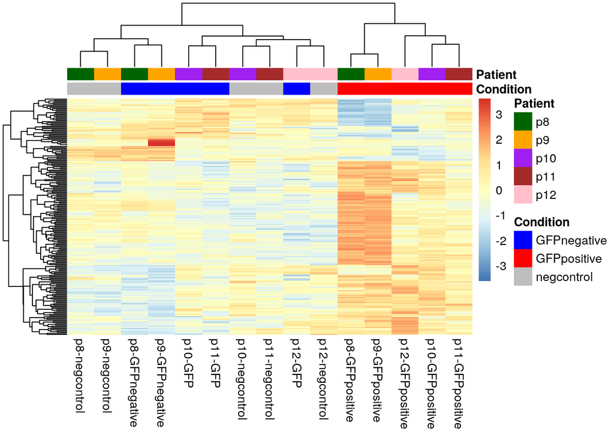

Figure 2. Top 200 differentially expressed genes (DEGs) for GFP positive versus GFP negative shown across different samples and conditions. At the top of the figure you can see which columns belong to a condition or patient by colour. As we can see, GFP positive genes tend to be more differentially expressed significantly more than negative control or GFP negative since we chose this as our coefficient for QLMTest.

```r
# Define a color scheme for conditions
condition_colors <- list(
  Condition = c(GFPnegative = "blue", GFPpositive = "red", negcontrol = "gray"),
  Patient = c(p8 = "darkgreen", p9 = "orange", p10 = "purple", p11 = "brown", p12 = "pink")
)


pheatmap::pheatmap(top_hits_expression,
         scale = "row",  # Scale by row (genes) to highlight expression patterns
         clustering_distance_rows = "euclidean",
         clustering_distance_cols = "euclidean",
         clustering_method = "complete",
         show_rownames = FALSE,  # Hide gene names for clarity
         annotation_col = sample_annotation,  # Include both Condition and Patient annotations
         annotation_colors = condition_colors)  # Add custom colors (optional)
```

As we can see in Figure 2, our conditions do tend to cluster together, notably GFP positive and GFP negative patient genes.

# 3 Gene List Enrichment Analysis

Gene list enrichment analysis is a common task in bioinformatics that helps identify biological pathways, processes, or functions that are overrepresented in a given gene list. We start with a list of genes and genesets/pathways from an annotation database.

## 3.1 Thresholded list

> 1. Which method did you choose and why?

First we separate the gene list by upregulated genes and down regulated genes. We can do this by using the log fold change and p-value. If a gene has log fold change less than 0 and p-value less than 0.05, it is indicative of a downregulated gene while a gene with log fold change greater than 0 and p-value less than 0.05 is indicative of an upregulated gene.

```r
# number of significant genes
sprintf("Number of significant genes (upregulated + downregulated): %d", length(which(qlf_output_hits$table$PValue < 0.05)))
```

```
## [1] "Number of significant genes (upregulated + downregulated): 1683"
```

```r
# number of significant upregulated genes
up_reg_genes <- qlf_output_hits[which(qlf_output_hits$table$PValue < 0.05 & qlf_output_hits$table$logFC > 0),]
sprintf("Number of upregulated genes: %d", nrow(up_reg_genes))
```

```
## [1] "Number of upregulated genes: 933"
```

```r
# number of significant upregulated genes
down_reg_genes <- qlf_output_hits[which(qlf_output_hits$table$PValue < 0.05 & qlf_output_hits$table$logFC < 0),]
sprintf("Number of downregulated genes: %d", nrow(down_reg_genes))
```

```
## [1] "Number of downregulated genes: 750"
```

```r
# Write to file
write.table(x=up_reg_genes,
            file=file.path(getwd(), "GFPpositive_GFPnegative_upregulated_genes.txt"),
            sep="\t",
            row.names=FALSE,
            col.names=FALSE,
            quote=FALSE)
write.table(x=down_reg_genes,
            file=file.path(getwd(), "GFPpositive_GFPnegative_downregulated_genes.txt"),
            sep="\t",
            row.names=FALSE,
            col.names=FALSE,
            quote=FALSE)
```

## 3.2 Running GOSt

> 2. What annotation data did you use and why? What version of the annotation are you using?

The annotation data I’m using is from GO Biological process (GO:BP)(Consortium 2000), WikiPathways (WP)(Kutmon et al. 2016), Reactome (REAC)(Fabregat et al. 2018), and Kyoto Encyclopedia of Genes and Genomes (KEGG)(Kanehisa and Goto 2000). I chose the first three as they are the ones I’m familiar with from our gprofiler tutorial and the KEGG database as I was interested in pathways specifically.

```r
# get HUGO gene names of up- and down-regulated genes
all_deg_names <- rownames(qlf_output_hits[which(qlf_output_hits$table$PValue < 0.05),])
upreg_gene_names <- rownames(up_reg_genes)
downreg_gene_names <- rownames(down_reg_genes)

# Run gost on all differentially expressed genes, even those that are not regulated (log fold change between -0.05 and 0.05)
all_degs_gost <- gprofiler2::gost(
  all_deg_names,
  multi_query = FALSE,
  organism = "hsapiens",
  sources = c("GO:BP", "WP", "REAC", "KEGG"),
  user_threshold=0.05,
  correction_method = "fdr"
)
# Run GOSt on upregulated and downregulated genes
upreg_genes_gost <- gprofiler2::gost(
  upreg_gene_names,
  multi_query = FALSE,
  organism = "hsapiens",
  sources = c("GO:BP", "WP", "REAC", "KEGG"),
  user_threshold=0.05,
  correction_method = "fdr"
)
downreg_genes_gost <- gprofiler2::gost(
  downreg_gene_names,
  multi_query = FALSE,
  organism = "hsapiens",
  sources = c("GO:BP", "WP", "REAC", "KEGG"),
  user_threshold=0.05,
  correction_method = "fdr"
)
```

We create a function that helps us get top terms by the source. This will help visualize what kind of data we are looking at. If the source is GO:BP we will likely be looking at biological processes. If the source is KEGG, then we are looking at pathways, etc.

```r
# Function to get top result for specific source
get_top_terms <- function(gost_results, source = "GO:BP", top_n = 5) {
  # Extract results
  results_df <- gost_results$result

  # Filter by source and sort by p-value
  top_terms <- results_df %>%
    filter(source == !!source) %>%
    arrange(p_value) %>%
    head(top_n)

  return(top_terms)
}
```

> 3. How many genesets were returned with what thresholds?

We used a 0.05 P-value threshold to determine if a result was significant. In total, 851 results were returned for All differentially expressed genes, 572 were returned for our upregulated gene list, and 406 were returned for our downregulated gene list.

> 4. Run the analysis using the up-regulated set of genes, and the down-regulated set of genes separately. How do these results compare to using the whole list (i.e all differentially expressed genes together vs. the up-regulated and down regulated differentially expressed genes separately)?

Here, we create a table which displays metadata about all the gene lists we ran ORA on. It contains data about the number of genes in the gene lists, the number of terms returned, and the number from each annotation set that was returned.

```r
gost_table <- data.frame(
  Type = c("Differentially Expressed", "Upregulated", "Downregulated"),
  NumGenes = c(length(all_deg_names),
               length(upreg_gene_names),
               length(downreg_gene_names)),
  NumTermsReturned = c(nrow(all_degs_gost$result),
                       nrow(upreg_genes_gost$result),
                       nrow(downreg_genes_gost$result)),
  Num_GOBP = c(length(which(all_degs_gost$result$source == "GO:BP")),
               length(which(upreg_genes_gost$result$source == "GO:BP")),
               length(which(downreg_genes_gost$result$source == "GO:BP"))),
  Num_WP = c(length(which(all_degs_gost$result$source == "WP")),
             length(which(upreg_genes_gost$result$source == "WP")),
             length(which(downreg_genes_gost$result$source == "WP"))),
  Num_REAC = c(length(which(all_degs_gost$result$source == "REAC")),
           length(which(upreg_genes_gost$result$source == "REAC")),
           length(which(downreg_genes_gost$result$source == "REAC"))),
  Num_KEGG = c(length(which(all_degs_gost$result$source == "KEGG")),
         length(which(upreg_genes_gost$result$source == "KEGG")),
         length(which(downreg_genes_gost$result$source == "KEGG")))
)
knitr::kable(gost_table, caption="Table 1. Metadata table on gost results on the three gene lists we passed through: All significant differentially expressed genes, Upregulated genes, and Downregulated genes. ")
```

Table 1. Metadata table on gost results on the three gene lists we passed through: All significant differentially expressed genes, Upregulated genes, and Downregulated genes.

| Type | NumGenes | NumTermsReturned | Num_GOBP | Num_WP | Num_REAC | Num_KEGG |
| --- | --- | --- | --- | --- | --- | --- |
| Differentially Expressed | 1683 | 851 | 847 | 0 | 0 | 4 |
| Upregulated | 933 | 572 | 524 | 0 | 29 | 19 |
| Downregulated | 750 | 406 | 405 | 0 | 0 | 1 |

As we can see most of the results are GO Biological Process (GO:BP) terms. This is likely due to how GO:BP database covers a wide range of biological activities, both broad and specific. In contrast, KEGG, REAC, and WP pertain to more speicfic pathways and processes, thus making it more difficult for terms to have a higher statistical signficance.

Since GO:BP returns the most searches, let’s look at the top 5 GO:BP terms for each of the gene lists.

```r
# Getting the top 5 GO terms for GO:BP across the three to see if there's any overlap
all_gobp_top_5 <- get_top_terms(all_degs_gost, top_n=5)
up_gobp_top_5 <- get_top_terms(upreg_genes_gost, top_n=5)
down_gobp_top_5 <- get_top_terms(downreg_genes_gost, top_n=5)

top_gobp_table <- data.frame(
  All_DEGs = all_gobp_top_5$term_name,
  Upregulated = up_gobp_top_5$term_name,
  Downregulated = down_gobp_top_5$term_name
)
knitr::kable(top_gobp_table, caption="Table 2. Top 5 GO:BP terms for the 3 gene lists: all differential expressed genes (ALL_DEGs), Upregulated genes, and Downregulated genes.")
```

Table 2. Top 5 GO:BP terms for the 3 gene lists: all differential expressed genes (ALL_DEGs), Upregulated genes, and Downregulated genes.

| All_DEGs | Upregulated | Downregulated |
| --- | --- | --- |
| developmental process | biological regulation | developmental process |
| anatomical structure development | signaling | anatomical structure development |
| multicellular organismal process | cell communication | multicellular organism development |
| signaling | response to stimulus | system development |
| cell communication | multicellular organismal process | response to endogenous stimulus |

Interestingly, the upregulated gene list contains more genes for KEGG and REAC. We can also investigate these terms further as well for just upregulated genes.

```r
up_reac_top_5 <- get_top_terms(upreg_genes_gost, source="REAC", top_n=5)
up_kegg_top_5 <- get_top_terms(upreg_genes_gost, source="KEGG", top_n=5)
top_gobp_table <- data.frame(
  Upregulated_REAC = up_reac_top_5$term_name,
  Upregulated_KEGG = up_kegg_top_5$term_name,
  Upregulated_GOBP = up_gobp_top_5$term_name
)
knitr::kable(top_gobp_table, caption="Table 3. Top 5 REAC, KEGG, and GO:BP terms for Upregulated genes.")
```

Table 3. Top 5 REAC, KEGG, and GO:BP terms for Upregulated genes.

| Upregulated_REAC | Upregulated_KEGG | Upregulated_GOBP |
| --- | --- | --- |
| Cytokine Signaling in Immune system | Phagosome | biological regulation |
| Signal Transduction | Systemic lupus erythematosus | signaling |
| Interferon gamma signaling | Type I diabetes mellitus | cell communication |
| Senescence-Associated Secretory Phenotype (SASP) | JAK-STAT signaling pathway | response to stimulus |
| Adrenaline signalling through Alpha-2 adrenergic receptor | Allograft rejection | multicellular organismal process |

From these analyses, it is clear that there is a strong difference in analyzing each gene list individually, such as upregulation versus downregulation for ORA.

# 4 Interpretation

# Works Cited

Chen, Yunshun, Aaron A T Lun, and Gordon K Smyth. 2016. “From Reads to Genes to Pathways: Differential Expression Analysis of RNA-Seq Experiments Using Rsubread and the edgeR Quasi-Likelihood Pipeline.” *F1000Research* 5: 1438. https://doi.org/10.12688/f1000research.8987.2.

Consortium, The Gene Ontology. 2000. “Gene Ontology: Tool for the Unification of Biology.” *Nature Genetics* 25 (1): 25–29. https://doi.org/10.1038/75556.

Fabregat, Antonio, Steven Jupe, Lisa Matthews, Konstantinos Sidiropoulos, Marc Gillespie, Phani Garapati, Robin Haw, et al. 2018. “Reactome: A Knowledgebase of Biological Pathways.” *Nucleic Acids Research* 46 (D1): D649–55. https://doi.org/10.1093/nar/gkx1132.

Kanehisa, Minoru, and Susumu Goto. 2000. “KEGG: Kyoto Encyclopedia of Genes and Genomes.” *Nucleic Acids Research* 28 (1): 27–30. https://doi.org/10.1093/nar/28.1.27.

Kolde, Raivo. 2018. *Pheatmap: Pretty Heatmaps*. https://github.com/raivokolde/pheatmap.

Kutmon, Martina, Anwesha Bohler, Julia Nunes, Kristina Hanspers, Andra Waagmeester, Egon L. Willighagen, Daniela Digles, et al. 2016. “WikiPathways: A Multifaceted Pathway Database Bridging Metabolomics to Other Omics Research.” *Nucleic Acids Research* 44 (D1): D481–87. https://doi.org/10.1093/nar/gkv1024.

Liis Kolberg, Ivan Kuzmin, Uku Raudvere. 2023. *G:profiler—Interoperable Web Service for Functional Enrichment Analysis and Gene Identifier Mapping*. https://doi.org/10.1093/nar/gkad347.

Morgan, Martin, and Marcel Ramos. 2023. *BiocManager: Access the Bioconductor Project Package Repository*. https://CRAN.R-project.org/package=BiocManager.

Petrof, Gabriela, Arti Nanda, Jake Howden, Takuya Takeichi, James R. McMillan, Sophia Aristodemou, Linda Ozoemena, et al. 2014. “Mutations in GRHL2 Result in an Autosomal-Recessive Ectodermal Dysplasia Syndrome.” *American Journal of Human Genetics* 95 (3): 308–14. https://doi.org/10.1016/j.ajhg.2014.08.001.

Wang, Coban, Z. 2023. “GRHL2-Controlled Gene Expression Networks in Luminal Breast Cancer.” *Cell Commun Signal* 21 (15). https://doi.org/10.1186/s12964-022-01029-5.

Wickham, Hadley. 2016. *Ggplot2: Elegant Graphics for Data Analysis*. https://ggplot2.tidyverse.org.

Xie, Yihui. 2014. “Knitr: A Comprehensive Tool for Reproducible Research in R.” In *Implementing Reproducible Computational Research*, edited by Victoria Stodden, Friedrich Leisch, and Roger D. Peng. Chapman; Hall/CRC.

Zheng, Christy, Kaelyn O. Allen, Tianrui Liu, Natalia M. Solodin, Mark B. Meyer, Kelley Salem, Phillipos K. Tsourkas, et al. 2024. “Elevated GRHL2 Imparts Plasticity in ER-Positive Breast Cancer Cells.” *Cancers* 16 (16): 2906. https://doi.org/10.3390/cancers16162906.